# Causal Conditional ComBat

Eric W. Bridgeford

2024-03-01

```r
require(causalBatch)
require(ggplot2)
require(tidyr)
n = 200
```

To start, we will begin with a simulation example, similar to the ones we were working in for the simulations, which you can access from:

```r
vignette("cb.simulations", package="causalBatch")
```

Let’s regenerate our working example data with some plotting code:

```r
# a function for plotting a scatter plot of the data
plot.sim <- function(Ys, Ts, Xs, title="",
                     xlabel="Covariate",
                     ylabel="Outcome (1st dimension)") {
  data = data.frame(Y1=Ys[,1], Y2=Ys[,2],
                    Group=factor(Ts, levels=c(0, 1), ordered=TRUE),
                    Covariates=Xs)

  data %>%
    ggplot(aes(x=Covariates, y=Y1, color=Group)) +
    geom_point() +
    labs(title=title, x=xlabel, y=ylabel) +
    scale_x_continuous(limits = c(-1, 1)) +
    scale_color_manual(values=c(`0`="#bb0000", `1`="#0000bb"),
                       name="Group/Batch") +
    theme_bw()
}
```

Next, we will generate a simulation:

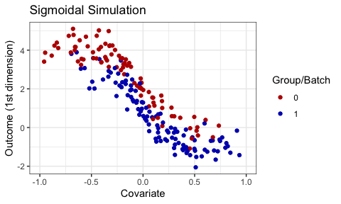

```r
sim = cb.sims.sim_sigmoid(n=n, eff_sz=1, unbalancedness=1.5)

plot.sim(sim$Ys, sim$Ts, sim$Xs, title="Sigmoidal Simulation")
```

It looks like the red group/batch tends to have outcomes exceeding the blue group/batch. We can test whether a group/batch effect can be detected. See the vignette on causal conditional distance correlation for more details, found at:

```r
vignette("cb.detect.caus_cdcorr", package="causalBatch")
```

Now to run the test and evaluate with $\alpha = 0.05$:

```r
result <- cb.detect.caus_cdcorr(sim$Ys, sim$Ts, sim$Xs, R=100)
print(sprintf("p-value: %.4f", result$Test$p.value))
```

```
#> [1] "p-value: 0.0099"
```

Since the $p$-value is $< \alpha$, this indicates that the data provide evidence to reject the null hypothesis in favor of the alternative (there is a causal group/batch effect). Next, we can correct for this effect using causal conditional ComBat. Note in particular that the covariates should be passed as a named data frame:

```r
cor.sim <- cb.correct.caus_cComBat(sim$Ys, sim$Ts, data.frame(Covar=sim$Xs),
                                   match.form="Covar")
```

```
#> Found2batches
#> Adjusting for1covariate(s) or covariate level(s)
#> Standardizing Data across genes
#> Fitting L/S model and finding priors
#> Finding parametric adjustments
#> Adjusting the Data
```

We can plot the augmented data after causal conditional ComBat has been applied, like so:

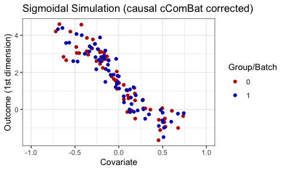

```r
plot.sim(cor.sim$Ys.corrected, cor.sim$Ts, cor.sim$Xs$Covar,
         title="Sigmoidal Simulation (causal cComBat corrected)")
```

We can see that the augmented data nearly perfectly overlaps across the two groups/batches, which can be confirmed using the causal conditional distance correlation:

```r
result.cor <- cb.detect.caus_cdcorr(cor.sim$Ys.corrected, cor.sim$Ts,
                                    cor.sim$Xs$Covar, R=100)
print(sprintf("p-value: %.4f", result.cor$Test$p.value))
```

```
#> [1] "p-value: 1.0000"
```

If we have multiple covariate values, you can specify custom formulas for the matching process using the standard R formula notation. For instance, if we had a second covariate value:

```r
Xs.2covar <- data.frame(Covar1=sim$Xs, Covar2=runif(n))
```

You could specify a formula instead like this:

```r
cor.sim <- cb.correct.caus_cComBat(sim$Ys, sim$Ts, Xs.2covar,
                                   match.form="Covar1 + Covar2")
```

```
#> Found2batches
#> Adjusting for2covariate(s) or covariate level(s)
#> Standardizing Data across genes
#> Fitting L/S model and finding priors
#> Finding parametric adjustments
#> Adjusting the Data
```

You can also use the standard `MatchIt::matchit()` arguments to leverage custom matching algorithms. These are passed into the function using the `match.args` argument. For instance, consider if we have a third categorical covariate:

```r
Xs.3covar <- cbind(data.frame(Cat.Covar=factor(rbinom(n, size=1, 0.5))),
                   Xs.2covar)
```

If we wanted to leverage exact matching for the categorical covariate, we could specify to perform exact matching for `Cat.Covar`, and leave nearest-neighbor matching (without replacement) for `Covar1` and `Covar2`, exactly as you would for the `MatchIt::matchit()` package:

```r
match.args <- list(method="nearest", exact="Cat.Covar", replace=FALSE,
                   caliper=0.1)
cor.sim <- cb.correct.caus_cComBat(sim$Ys, sim$Ts, Xs.3covar,
                                   match.form="Covar1 + Covar2 + Cat.Covar",
                                   match.args=match.args)
```

```
#> Found2batches
#> Adjusting for3covariate(s) or covariate level(s)
#> Standardizing Data across genes
#> Fitting L/S model and finding priors
#> Finding parametric adjustments
#> Adjusting the Data
```